# Video Games Sales Analysis by Bayan AlArifi

> This report explores a dataset generated by a scrape of vgchartz.com. The scraping script is available at https://github.com/GregorUT/vgchartzScrape. The dataset contains video games sales and attributes for approximately 11493 video games. The dataset contains 16,598 observations and 11 variables.

These variables are:

```
##  [1] "Rank"         "Name"         "Platform"     "Year"
##  [5] "Genre"        "Publisher"    "NA_Sales"     "EU_Sales"
##  [9] "JP_Sales"     "Other_Sales"  "Global_Sales"
```

A summary of various model fitting functions’ results for each of the variables/features:

```
##       Rank                                Name          Platform
##  Min.   :    1   Need for Speed: Most Wanted:   12   DS     :2163
##  1st Qu.: 4151   FIFA 14                    :    9   PS2    :2161
##  Median : 8300   LEGO Marvel Super Heroes   :    9   PS3    :1329
##  Mean   : 8301   Madden NFL 07              :    9   Wii    :1325
##  3rd Qu.:12450   Ratatouille                :    9   X360   :1265
##  Max.   :16600   Angry Birds Star Wars      :    8   PSP    :1213
##                  (Other)                    :16542   (Other):7142
##       Year               Genre                             Publisher
##  2009   :1431   Action      :3316   Electronic Arts             : 1351
##  2008   :1428   Sports      :2346   Activision                  :  975
##  2010   :1259   Misc        :1739   Namco Bandai Games          :  932
##  2007   :1202   Role-Playing:1488   Ubisoft                     :  921
##  2011   :1139   Shooter     :1310   Konami Digital Entertainment:  832
##  2006   :1008   Adventure   :1286   THQ                         :  715
##  (Other):9131   (Other)     :5113   (Other)                     :10872
##     NA_Sales          EU_Sales          JP_Sales         Other_Sales
##  Min.   : 0.0000   Min.   : 0.0000   Min.   : 0.00000   Min.   : 0.00000
##  1st Qu.: 0.0000   1st Qu.: 0.0000   1st Qu.: 0.00000   1st Qu.: 0.00000
##  Median : 0.0800   Median : 0.0200   Median : 0.00000   Median : 0.01000
##  Mean   : 0.2647   Mean   : 0.1467   Mean   : 0.07778   Mean   : 0.04806
##  3rd Qu.: 0.2400   3rd Qu.: 0.1100   3rd Qu.: 0.04000   3rd Qu.: 0.04000
##  Max.   :41.4900   Max.   :29.0200   Max.   :10.22000   Max.   :10.57000
##
##   Global_Sales
##  Min.   : 0.0100
##  1st Qu.: 0.0600
##  Median : 0.1700
##  Mean   : 0.5374
##  3rd Qu.: 0.4700
##  Max.   :82.7400
##
```

Checking the first couple of rows..

```
##   Rank                     Name Platform Year        Genre Publisher
## 1    1               Wii Sports      Wii 2006       Sports  Nintendo
## 2    2        Super Mario Bros.      NES 1985     Platform  Nintendo
## 3    3           Mario Kart Wii      Wii 2008       Racing  Nintendo
## 4    4        Wii Sports Resort      Wii 2009       Sports  Nintendo
## 5    5 Pokemon Red/Pokemon Blue       GB 1996 Role-Playing  Nintendo
## 6    6                   Tetris       GB 1989       Puzzle  Nintendo
##   NA_Sales EU_Sales JP_Sales Other_Sales Global_Sales
## 1    41.49    29.02     3.77        8.46        82.74
## 2    29.08     3.58     6.81        0.77        40.24
## 3    15.85    12.88     3.79        3.31        35.82
## 4    15.75    11.01     3.28        2.96        33.00
## 5    11.27     8.89    10.22        1.00        31.37
## 6    23.20     2.26     4.22        0.58        30.26
```

# Univariate Plots Section

The feature/variable Rank is the rank of the 16327 video games in the dataset considering their global sales, where rank #1 is the top selling. Thus, there was no need to plot it here.

**Global Sales**

Since 1980, video games global sales reached a total of 8920.44 million.

```
##    Min. 1st Qu.  Median    Mean 3rd Qu.    Max.
##  0.0100  0.0600  0.1700  0.5374  0.4700 82.7400
```

```
## [1] 8920.44
```

**Yearly Releases**

```
## 1980 1981 1982 1983 1984 1985 1986 1987 1988 1989 1990 1991 1992 1993 1994
##    9   46   36   17   14   14   21   16   15   17   16   41   43   60  121
## 1995 1996 1997 1998 1999 2000 2001 2002 2003 2004 2005 2006 2007 2008 2009
##  219  263  289  379  338  349  482  829  775  763  941 1008 1202 1428 1431
## 2010 2011 2012 2013 2014 2015 2016 2017 2020  N/A
## 1259 1139  657  546  582  614  344    3    1    0
```

Most video games were released in 2008 (1428 games) and 2009 (1431 games).

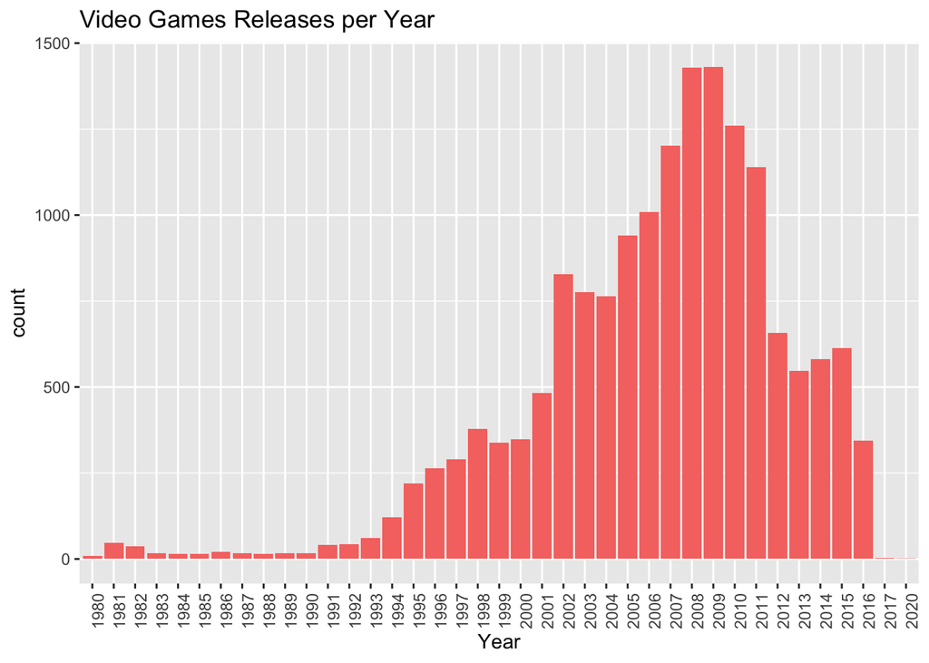

**Video Games Releases**

```
##                               Need for Speed: Most Wanted
##                                                        12
##                                                   FIFA 14
##                                                         9
##                                  LEGO Marvel Super Heroes
##                                                         9
##                                               Ratatouille
##                                                         9
##                                     Angry Birds Star Wars
##                                                         8
##                                                      Cars
##                                                         8
##                                                   FIFA 15
##                                                         8
##                                            FIFA Soccer 13
##                                                         8
##                              Lego Batman 3: Beyond Gotham
##                                                         8
##                                       LEGO Jurassic World
##                                                         8
##                   LEGO Star Wars II: The Original Trilogy
##                                                         8
##                                           LEGO The Hobbit
##                                                         8
##                                             Madden NFL 07
##                                                         8
##                                             Madden NFL 08
##                                                         8
##                                                  Monopoly
##                                                         8
##                                                  Terraria
##                                                         8
##                                  The LEGO Movie Videogame
##                                                         8
##                                                   FIFA 12
##                                                         7
##                                            FIFA Soccer 08
##                                                         7
##                                            FIFA Soccer 10
##                                                         7
```

[output cut: 145 more lines]

```
##                                                         6
##                                               Open Season
##                                                         6
## Peter Jackson's King Kong: The Official Game of the Movie
##                                                         6
##                  Pirates of the Caribbean: At World's End
##                                                         6
##                     Prince of Persia: The Forgotten Sands
##                                                         6
##                                 Pro Evolution Soccer 2008
##                                                         6
##                                 Pro Evolution Soccer 2010
##                                                         6
##                                                   (Other)
##                                                     15663
```

The top released video game is ‘Need for Speed: Most Wanted’.

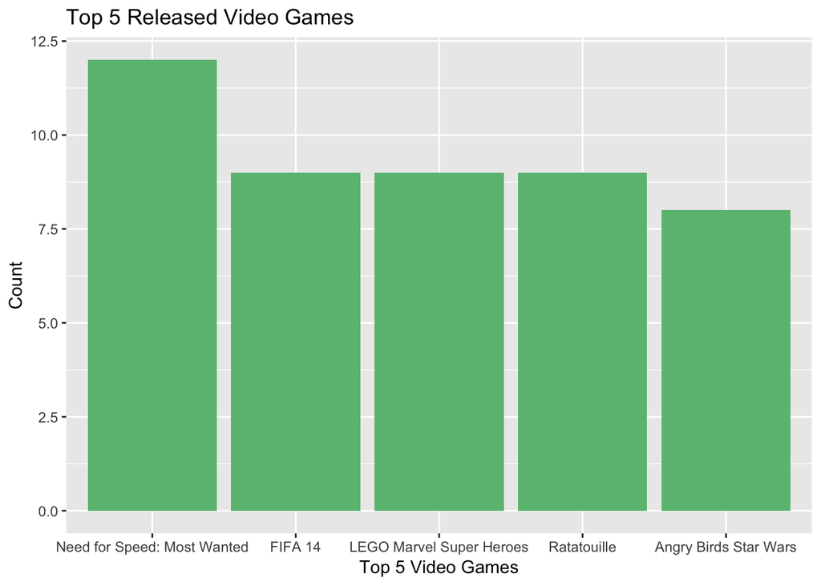

**Platforms**

```
## 2600  3DO  3DS   DC   DS   GB  GBA   GC  GEN   GG  N64  NES   NG   PC PCFX
##  116    3  500   52 2133   97  811  542   27    1  316   98   12  943    1
##   PS  PS2  PS3  PS4  PSP  PSV  SAT  SCD SNES TG16  Wii WiiU   WS X360   XB
## 1189 2127 1304  336 1197  412  173    6  239    2 1290  143    6 1235  803
## XOne
##  213
```

The top releasing video game platforms are PS2 (2127) and DS (2133), out of 31 total platforms.

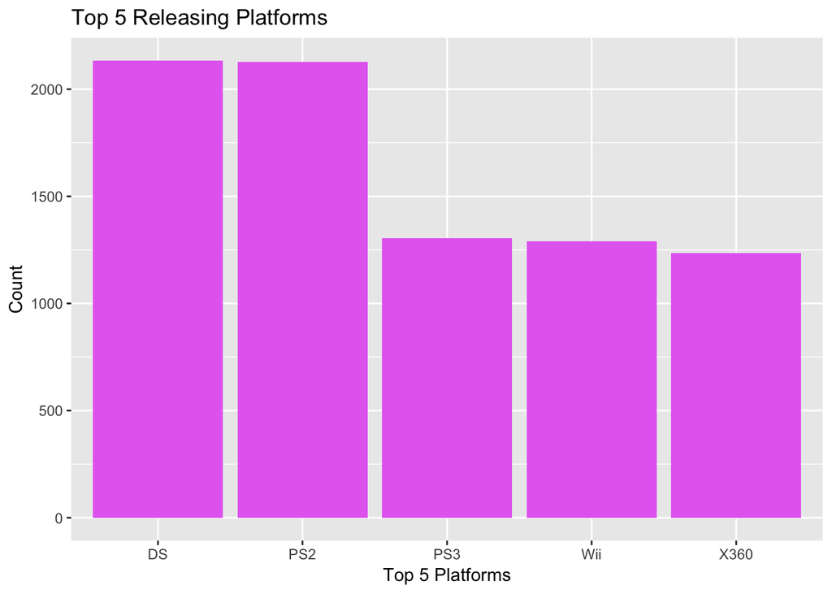

**Publishers**

```
##                        Electronic Arts
##                                   1339
##                             Activision
##                                    966
##                     Namco Bandai Games
##                                    928
##                                Ubisoft
##                                    918
##           Konami Digital Entertainment
##                                    823
##                                    THQ
##                                    712
##                               Nintendo
##                                    696
##            Sony Computer Entertainment
##                                    682
##                                   Sega
##                                    632
##                   Take-Two Interactive
##                                    412
##                                 Capcom
##                                    376
##                                  Atari
##                                    347
##                             Tecmo Koei
##                                    338
##                            Square Enix
##                                    231
## Warner Bros. Interactive Entertainment
##                                    217
##             Disney Interactive Studios
##                                    214
##                      Eidos Interactive
##                                    196
##                           Midway Games
##                                    196
##                              505 Games
##                                    192
##                 Microsoft Game Studios
##                                    189
```

[output cut: 145 more lines]

```
##                                     19
##                               ChunSoft
##                                     18
##                       City Interactive
##                                     18
##                           SNK Playmore
##                                     18
##                       Tomy Corporation
##                                     18
##                            Zushi Games
##                                     18
##               DreamCatcher Interactive
##                                     17
##                                (Other)
##                                   1868
```

The top video games publisher is Electronic Arts (1339), out of a total of 579 publishers.

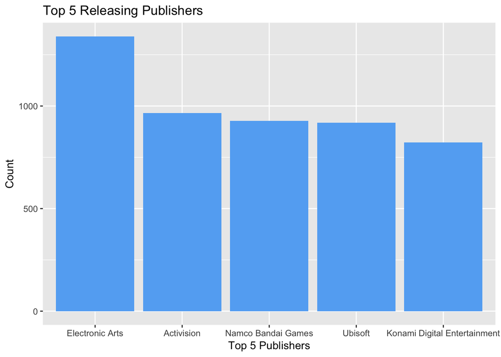

**Genres**

```
##       Action    Adventure     Fighting         Misc     Platform
##         3253         1276          836         1710          876
##       Puzzle       Racing Role-Playing      Shooter   Simulation
##          571         1226         1471         1282          851
##       Sports     Strategy
##         2304          671
```

The top selling video games genre is Action with a total of 3253 video game releases, out of a total of 12 genres. Action Games contribute to almost 20% of the games released. Sports games coming in second with 14% (2304 releases). Overall all top 5 genres contribute to 61% of the games released.

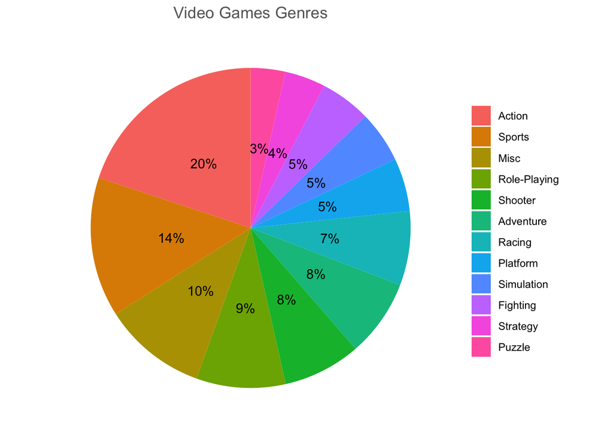

# Univariate Analysis

### What is the structure of your dataset?

There are 16,598 observations about 11493 video games, with 11 features, as descrived below.

**Variables Dictionary:**

- Rank - Ranking of overall sales
- Name - The games name
- Platform - Platform of the games release (i.e. PC,PS4, etc.)
- Year - Year of the game’s release
- Genre - Genre of the game
- Publisher - Publisher of the game
- NA_Sales - Sales in North America (in millions)
- EU_Sales - Sales in Europe (in millions)
- JP_Sales - Sales in Japan (in millions)
- Other_Sales - Sales in the rest of the world (in millions)
- Global_Sales - Total worldwide sales.

```
## 'data.frame':    16327 obs. of  11 variables:
##  $ Rank        : int  1 2 3 4 5 6 7 8 9 10 ...
##  $ Name        : Factor w/ 11493 levels "¡Shin Chan Flipa en colores!",..: 10991 9343 5531 10993 7364 9707 6648 10989 6651 2594 ...
##  $ Platform    : Factor w/ 31 levels "2600","3DO","3DS",..: 26 12 26 26 6 6 5 26 26 12 ...
##  $ Year        : Factor w/ 40 levels "1980","1981",..: 27 6 29 30 17 10 27 27 30 5 ...
##  $ Genre       : Factor w/ 12 levels "Action","Adventure",..: 11 5 7 11 8 6 5 4 5 9 ...
##  $ Publisher   : Factor w/ 579 levels "10TACLE Studios",..: 369 369 369 369 369 369 369 369 369 369 ...
##  $ NA_Sales    : num  41.5 29.1 15.8 15.8 11.3 ...
##  $ EU_Sales    : num  29.02 3.58 12.88 11.01 8.89 ...
##  $ JP_Sales    : num  3.77 6.81 3.79 3.28 10.22 ...
##  $ Other_Sales : num  8.46 0.77 3.31 2.96 1 0.58 2.9 2.85 2.26 0.47 ...
##  $ Global_Sales: num  82.7 40.2 35.8 33 31.4 ...
```

### What is/are the main feature(s) of interest in your dataset?

The main features in the data set are Global_Sales and Year, and discovering the trend around them, i.e. what are the top globally selling value of the other features, and top other features values over time.

### What other features in the dataset do you think will help support your investigation into your feature(s) of interest?

The month of the year could likely contribute to the rise of sales. For example, certain video game genres could be always popular in a certain month of the year. It would be interesting to see how the other regions around the world’s sales do, rather than just having the variable Other_Sales. Lastly, demographic data on the buyers of these games could tell us a lot on why certain feature values happen to be more popular than others. In fact, such kind of data can also help us predict the future sales considering the buyers demographic and behaviour.

### Did you create any new variables from existing variables in the dataset?

In order to create the regional sales comparison plots in the **Multivariate** section, I needed to combine the regional sales columns (NA_Sales, EU_Sales, JP_Sales, Other_Sales, Global_Sales) by using the gather function from the tidyr package.

### Of the features you investigated, were there any unusual distributions? Did you perform any operations on the data to tidy, adjust, or change the form of the data? If so, why did you do this?

I had to drop observations where the Year had an N/A value.

# Bivariate Plots Section

**Global Sales per Year**

```
##    Min. 1st Qu.  Median    Mean 3rd Qu.    Max.
##    0.05   46.60  199.15  226.16  365.82  678.90
```

The highest global sales were in 2008, with a total of 678.90 million. 2009 comes in second with slightly less sales. On average, the yearly global sales reach 226.16 million as shown in the purple dashed line.

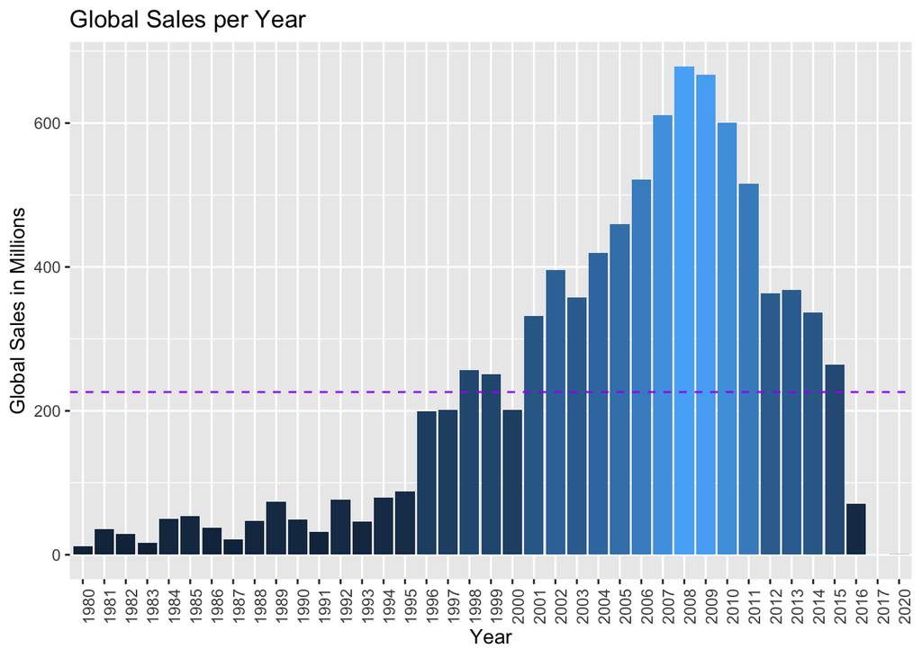

**Top Globally Selling Genres**

```
##    Min. 1st Qu.  Median    Mean 3rd Qu.    Max.
##   402.5   446.0   575.2   591.1   670.1   861.8
```

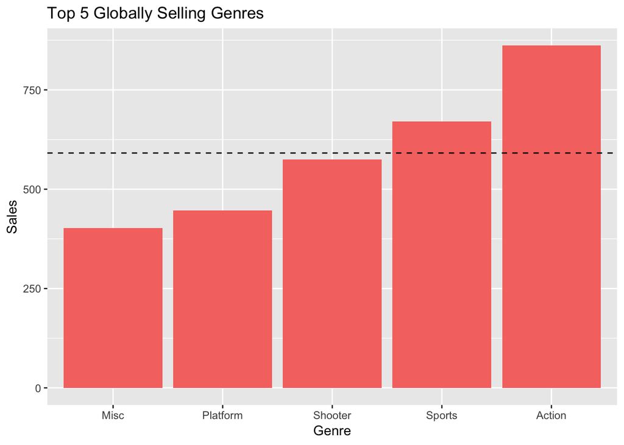

**Top Globally Selling Publishers**

```
##    Min. 1st Qu.  Median    Mean 3rd Qu.    Max.
##   473.5   607.3   721.4   936.0  1093.4  1784.4
```

The top globally selling video game publisher is Nintendo with 1784.4 million. On average, the global sales reach 936.0 million as shown in the black dashed line.

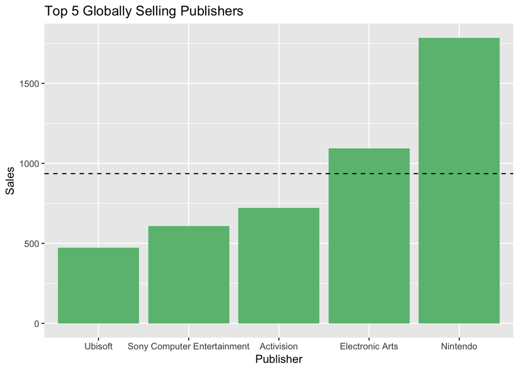

**Top Globally Selling Platforms**

```
##    Min. 1st Qu.  Median    Mean 3rd Qu.    Max.
##   819.0   909.8   949.4   976.2   969.6  1233.5
```

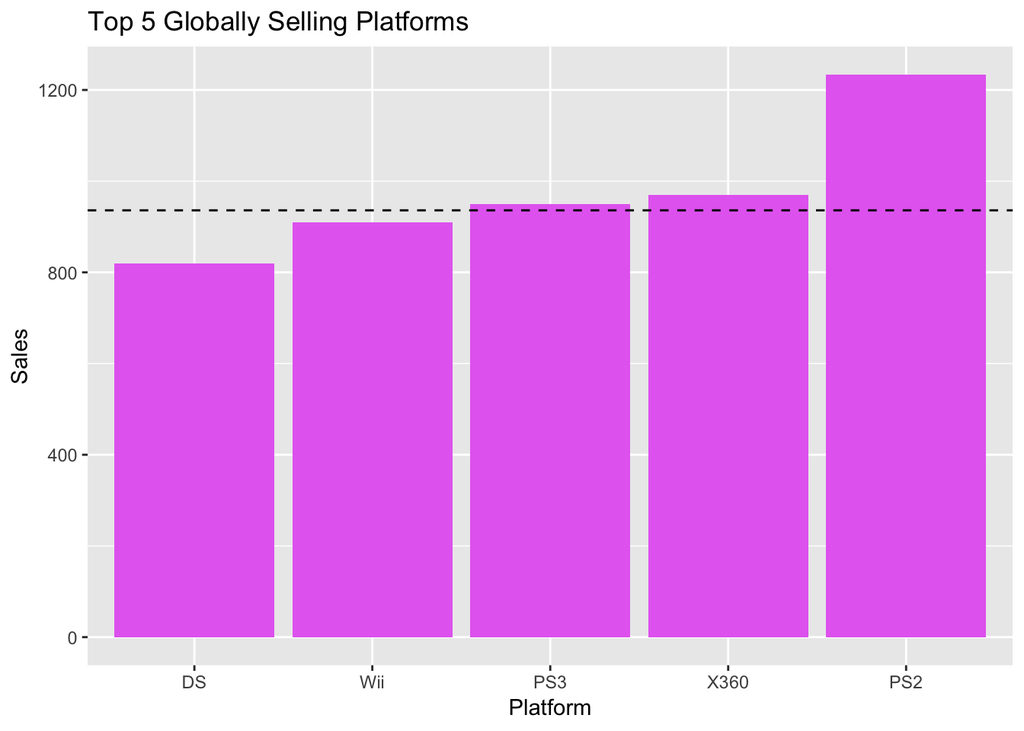

**Top Globally Selling Video Games**

```
##    Min. 1st Qu.  Median    Mean 3rd Qu.    Max.
##   35.82   35.84   45.31   51.13   55.92   82.74
```

The top globally selling video game is Wii Sport with 82.74 million. On average, the global sales reach 51.13 million as shown in the black dashed line.

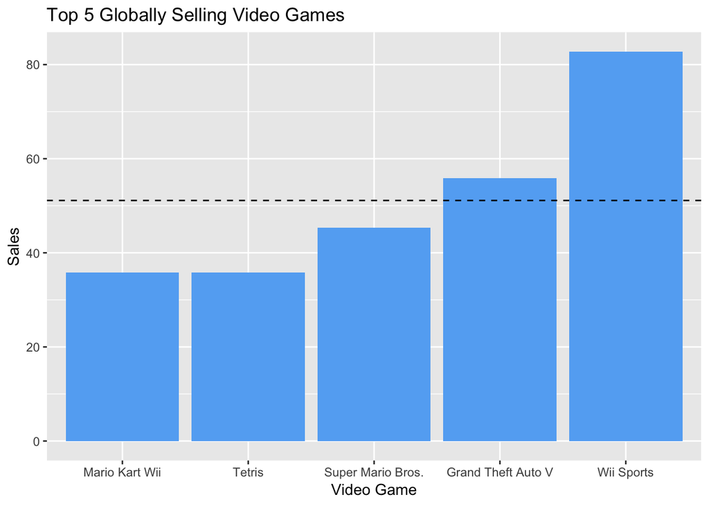

**Regional Sales**

The distribution of each regional sales variable is shown on the diagonal of the below plot. On the bottom of the diagonal, the bivariate scatter plots with a fitted line are displayed. On the top of the diagonal, the value of the correlation plus the significance level as stars. Each significance level is associated with a symbol: p-values(0, 0.001, 0.01, 0.05, 0.1, 1) <=> symbols(“***”, “**”, “*”, “.”, " “). As we can see in the matrix, NA_Sales (0.94) and EU_Sales (0.90) indicate an almost perfect positive correlation with Global_Sales. Moreover, if we look into the behavious of the NA_Salesand EU_Sales, they seem to move in the same direction. In general, all of the correlation coefficient values are greater than zero. Thus, there is a positive relationship between these variables.

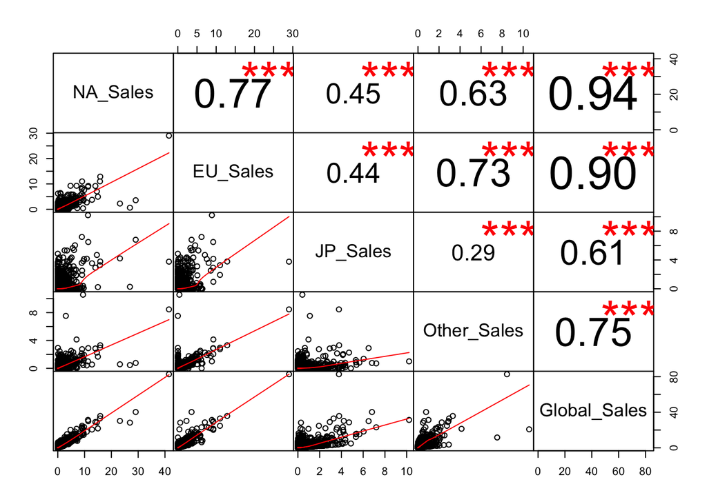

# Bivariate Analysis

### Talk about some of the relationships you observed in this part of the investigation. How did the feature(s) of interest vary with other features in the dataset?

2008 and 2009 were the most successful years for the game community. Action games are more famous nowadays. Nintendo and PS2 are behind the highest global sales. The top globally selling video game since 1980 is Wii Sports.

### Did you observe any interesting relationships between the other features (not the main feature(s) of interest)?

No, not in my bivariate analysis.

### What was the strongest relationship you found?

The one explained in the correlation matrix in the regional sales section.

# Multivariate Plots Section

**Globally Selling Genres per Year**

```
##    Min. 1st Qu.  Median    Mean 3rd Qu.    Max.
##    0.04   15.97   41.19   53.43   86.23  139.36
```

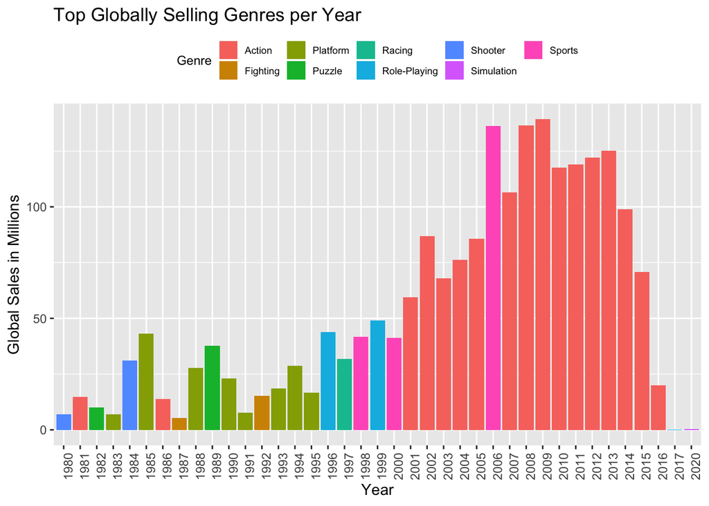

**Globally Selling Publishers per Year**

```
##    Min. 1st Qu.  Median    Mean 3rd Qu.    Max.
##    0.04   18.94   45.42   50.57   68.58  205.61
```

Nintendo is the top globally selling publishers since 1980 with 205.61 million in 2006. It also happens to be the top globally selling publisher in 24 years (1983-1994, 1996, 1998-2001, 2005-2009, 2012, 2014). Electronic Arts comes second. On a yearly average, top video game publisher sales reach 50.57 million.

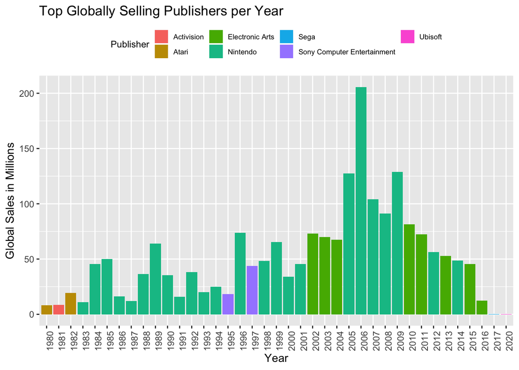

**Globally Selling Platfroms per Year**

```
##    Min. 1st Qu.  Median    Mean 3rd Qu.    Max.
##    0.03   35.42   94.68   92.34  157.17  211.78
```

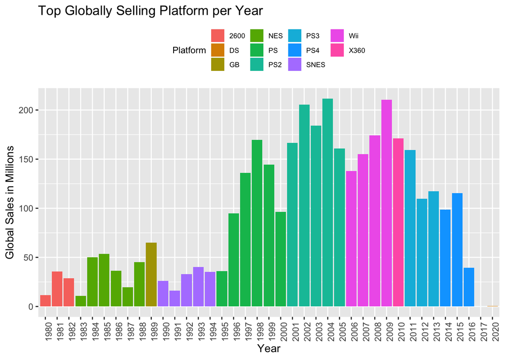

**Globally Selling Games per Year**

```
##    Min. 1st Qu.  Median    Mean 3rd Qu.    Max.
##    0.04    6.71   16.15   18.93   28.86   82.74
```

Wii Sports is the top globally selling game since 1980 with 82.74 million in 2006. Super Mario Bros. comes second in 1985. On a yearly average, top video games sales reach 18.93 million.

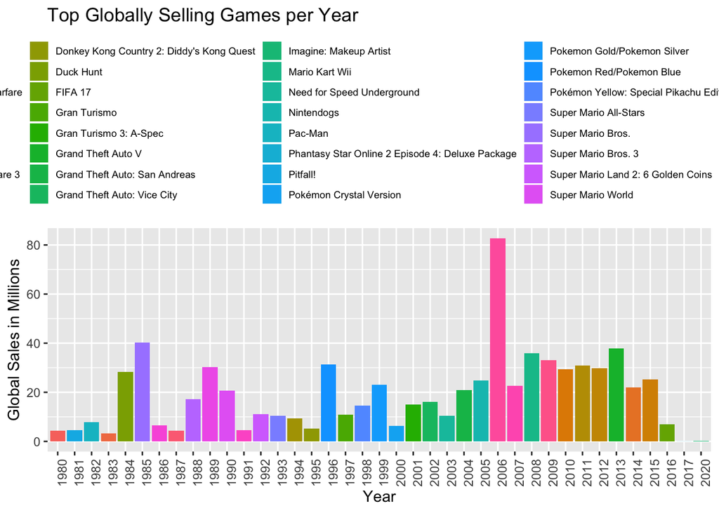

**Globally Selling Video Games per Platform**

```
##    Min. 1st Qu.  Median    Mean 3rd Qu.    Max.
##    0.03    2.09    7.81   13.06   18.23   82.74
```

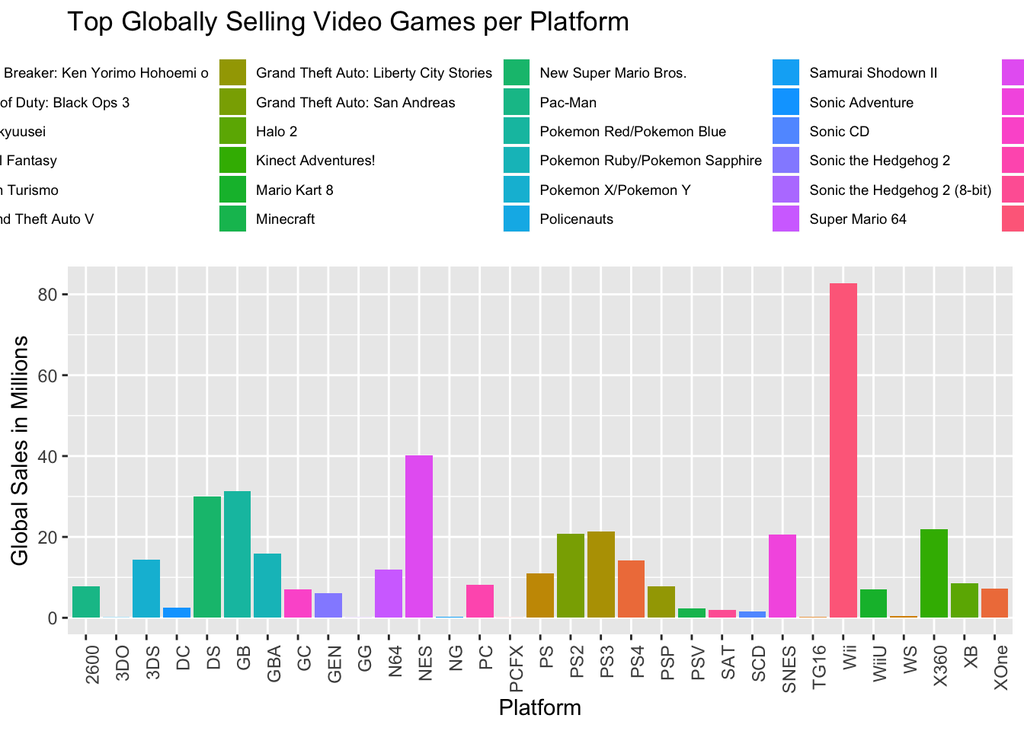

**Globally Selling Video Games per Genre**

```
##    Min. 1st Qu.  Median    Mean 3rd Qu.    Max.
##    5.45   21.83   31.10   33.45   38.21   82.74
```

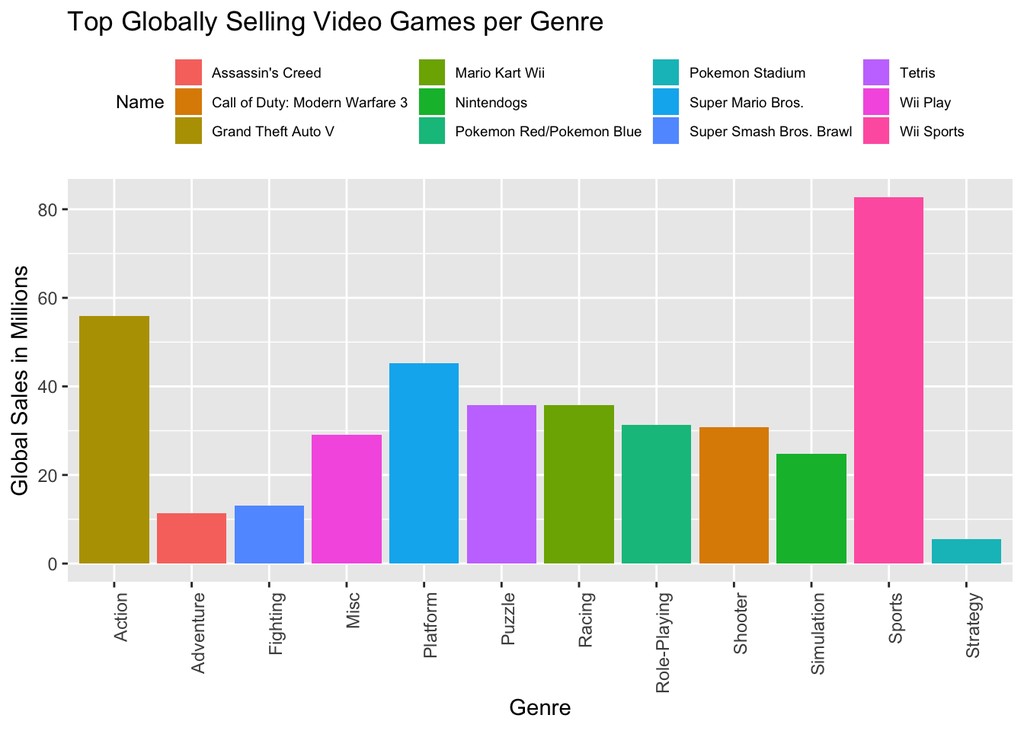

**Global and Regional Sales**

```
##    Min. 1st Qu.  Median    Mean 3rd Qu.    Max.
##  0.0100  0.0600  0.1700  0.5402  0.4800 82.7400
```

The below two plots illustrate a comparision of the regional and global sales. Follows that plots that show each region’s sales compared to the global ones over time.

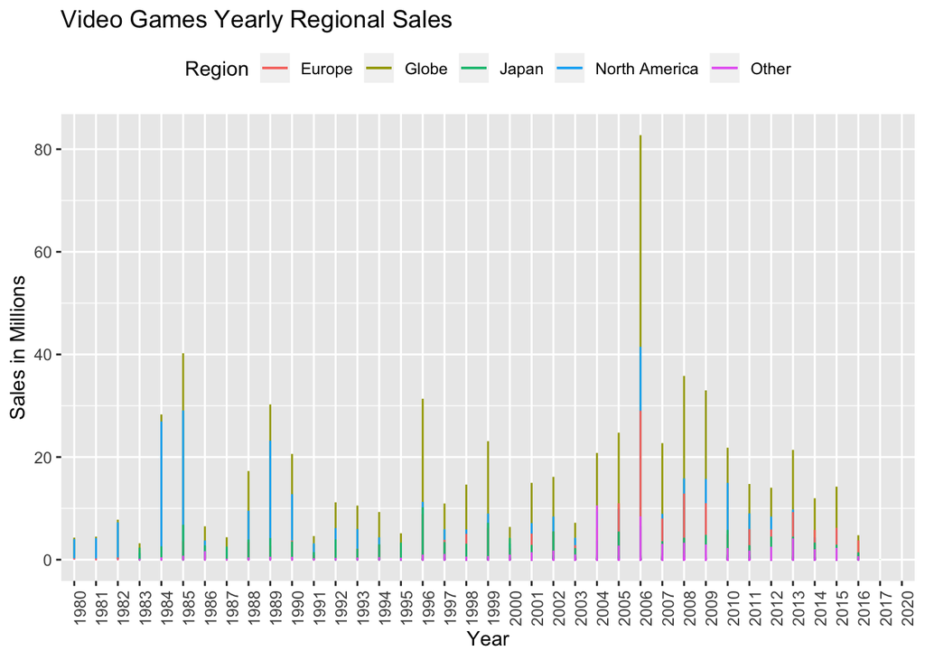

There is a huge fall in sales in the last 5-6 years, escpecially in the North American region.

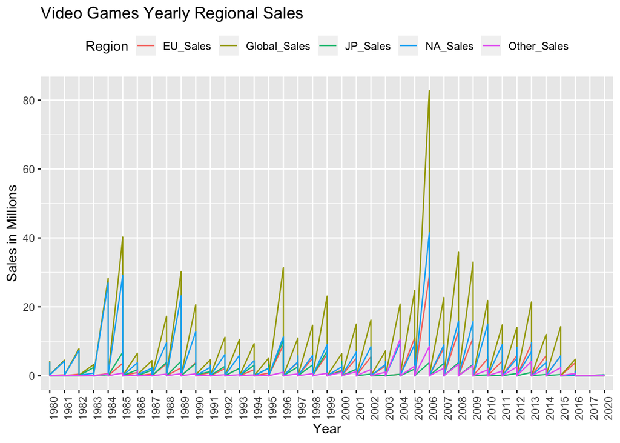

**Global and North America Yearly Sales**

```
##    Min. 1st Qu.  Median    Mean 3rd Qu.    Max.
##  0.0000  0.0000  0.0800  0.2654  0.2400 41.4900
```

The NA sales reached a peak of 41.4900 million in 2006. On average, their sales are 0.2654 million.

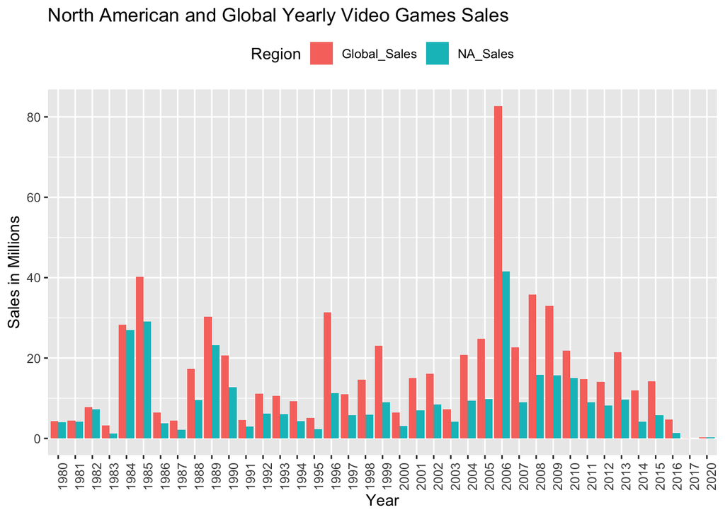

**Global and European Yearly Sales**

```
##    Min. 1st Qu.  Median    Mean 3rd Qu.    Max.
##  0.0000  0.0000  0.0200  0.1476  0.1100 29.0200
```

The EU sales reached a peak of 29.0200 million in 2006. On average, their sales are 0.1476 million.

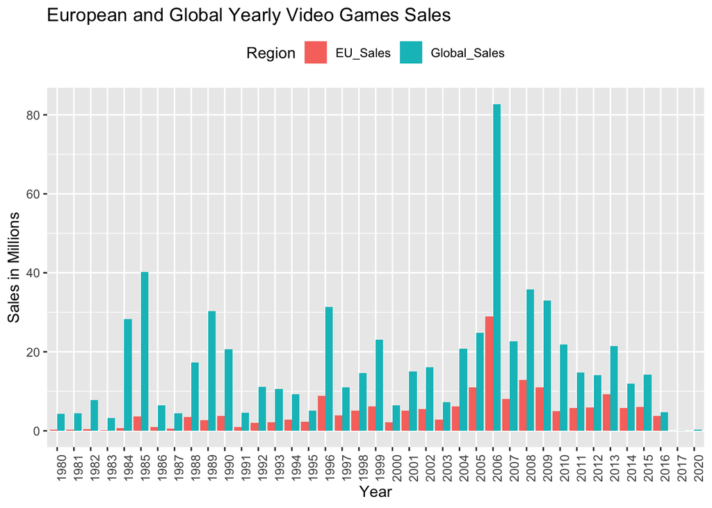

**Global and Japanese YearlySales**

```
##     Min.  1st Qu.   Median     Mean  3rd Qu.     Max.
##  0.00000  0.00000  0.00000  0.07866  0.04000 10.22000
```

The JP sales reached a peak of 10.22000 million in 1996. On average, their sales are 0.07866 million.

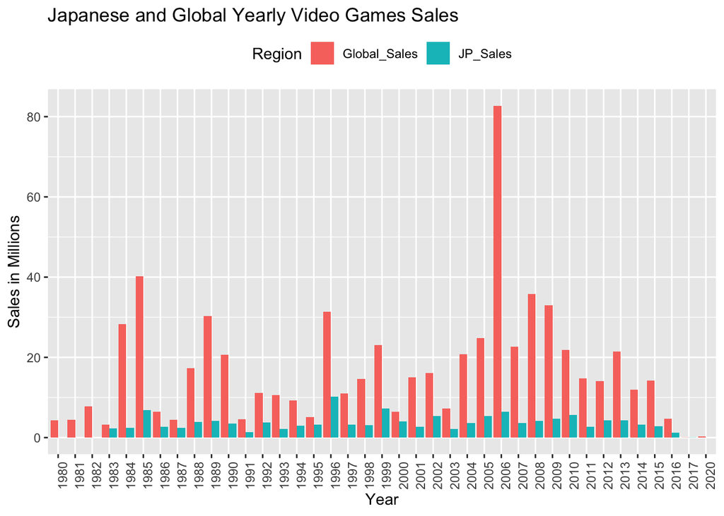

**Global and Other Yearly Sales**

```
##     Min.  1st Qu.   Median     Mean  3rd Qu.     Max.
##  0.00000  0.00000  0.01000  0.04832  0.04000 10.57000
```

The other regional sales reached a peak of 10.57000 million in 2004. On average, their sales are 0.04832 million.

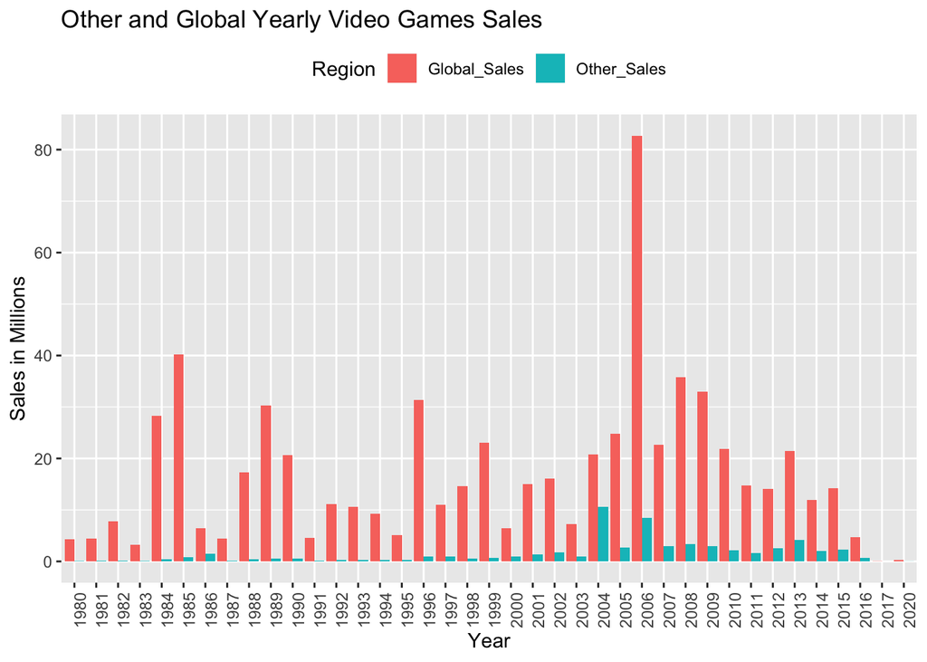

# Multivariate Analysis

### Talk about some of the relationships you observed in this part of the investigation. Were there features that strengthened each other in terms of looking at your feature(s) of interest?

Although the action genre was the popular famous since 2000, the second popular genre Sports (as we saw in the bivariat analysis) peaked in 2006. This was further confirmed after plotting A. the globally selling games per year and finding out it was Wii Sports from the Sports genre in 2006, and B. the globally selling games per genre, and C. the globally selling games platform which of course is Wii.

### Were there any interesting or surprising interactions between features?

The global and regional yearly sales for North America and Europe further confirm the results found in the correlation matrix, where the plots show that a rise in each of these regions whenever the global sales rises. On another note, the globally selling per year plots for publishers and platforms show an interesting pattern, where for example between 2006 and 2009 the Nintendo publisher was dominant, and the Wii platform was dominant. This makes sense since Nintendo owns Wii, and was released for the first time in November 19, 2006. Video game publishers that also happen to own platforms/consoles publish a couple of games that work with their new product to help market it. Other publishers follow to ensure a competitor’s advantage.

# Final Plots and Summary

### Plot One: **Globally Selling Platfroms per Year**

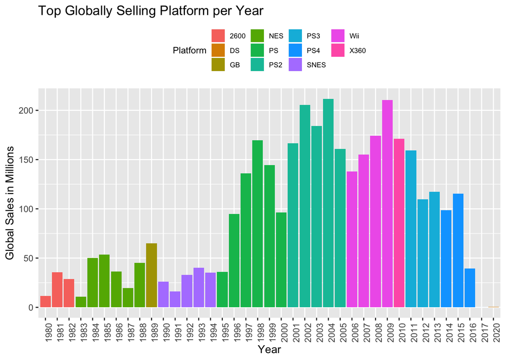

### Plot Two: **Top Globally Selling and Releasing Publishers**

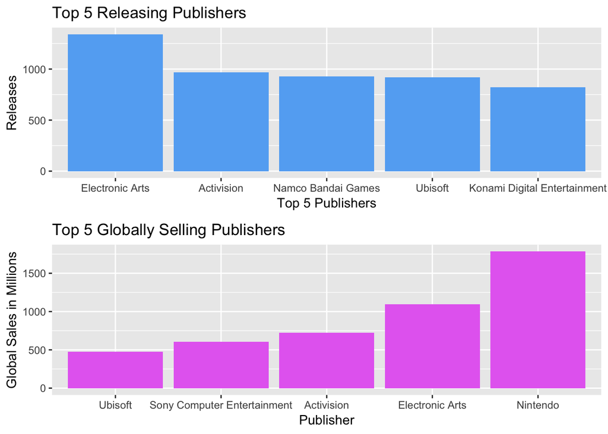

### Plot Three: **Yearly Global Sales and Releases**

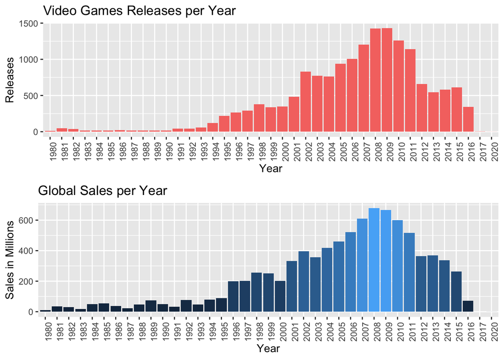

### Description Three Most video games were released in 2008 (1428 games) and 2009 (1431 games). The highest global sales were also in 2008, with a total of 678.90 million. 2009 comes in second with slightly less sales. Since 1996, the video game industry flourished. It continued to grow in the number of game releases, attracting more global sales, peaking in 2008-2009 as we can see in both plots of global sales/releases per year. We can also notice from the two plots that after the peak it started to gradually decrease.

# Reflection

One aspect that limited this analysis is the absence of the sales of other parts of the world, rather than just having the variable Other_Sales. Also, the month of the year could likely contribute to the rise of sales. For example, certain video game genres could be always popular in a certain month of the year. For future work, I would like to find data on the buyers demographic which could explain a lot of the resons behind the trends found, and improve the analysis. It will also help draw recommendations to the decision makers in this industry on where to focus their budget; which genre, which region, which platform, etc.